# Experiment 5: Calibration Analysis

As in the previous experiments, calibration score was defined as the average proportion of samples within 200 pixels of the validation point during the final validation phase before the eye tracking is performed. Where participants required more than one calibration (N=14), only the final calibration was considered.

To determine whether calibration accuracy influenced our key effects, we calculated the proportion of samples during the task in which the participant was fixating the face they ultimately chose. Calibration accuracy significantly correlated with fixations in the attractiveness condition (r = 0.5 [0.12, 0.75], p = 0.01) but not the roundness condition (r = 0.25 [-0.18, 0.6], p = 0.25). Inspection of Fig. @ref(fig:E5calcorr) reveals that this correlation is due to a handful of participants with calibration values below 50%.

(ref:E5calcorr-caption) Correlation between calibration accuracy (x-axis) and proportion of samples fixating target (y-axis) in Exp. 5.

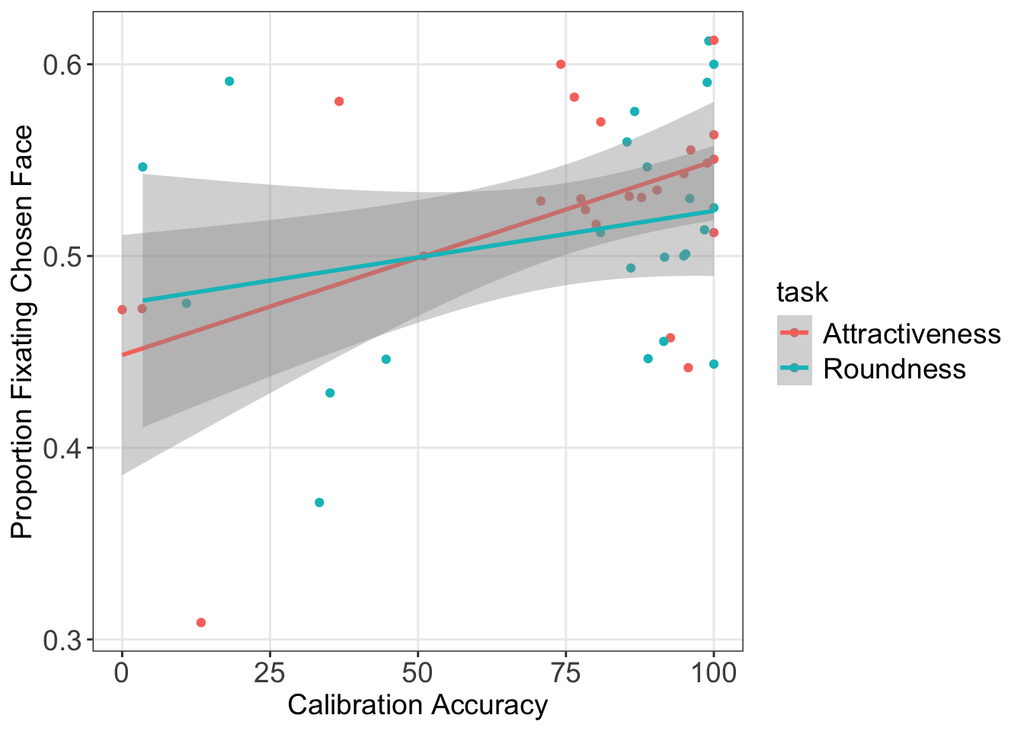

#### Re-analysis After Exclusions

As in the previous experiments, we re-analyzed the data, removing the participants whose calibration accuracy was not greater than 50%. This slightly improved the fits of the sigmoids (Attractiveness: R<sup>2</sup> = 0.78; Roundness: R<sup>2</sup> = 0.59). However, the difference between sigmoids remained non-significant using the Kolmogorov-Smirnov test (D = 0.2, p = 0.33). Descriptively, the results do not look substantially different (Fig. @ref(fig:groupEMainrev)).

(ref:groupEMainrev-caption-separate) Revised results for Exp. 5 after removing low-calibration accuracy participants. *Left*: Eyegaze during attractiveness judgments, along with the best-fitting sigmoid. *Right*: Eyegze during roundness judgments, along with best-fitting sigmoid (best-fitting sigmoid for attractiveness is re-plotted with a dashed line for comparison).

(ref:groupEMainrev-caption) Revised results for Exp. 5 after removing low-calibration accuracy participants. The proportion of fixations to the target in the two seconds prior to the judgment are shown for the attractiveness (red) and roundness (blue) conditions along with their best-fitting sigmoids.

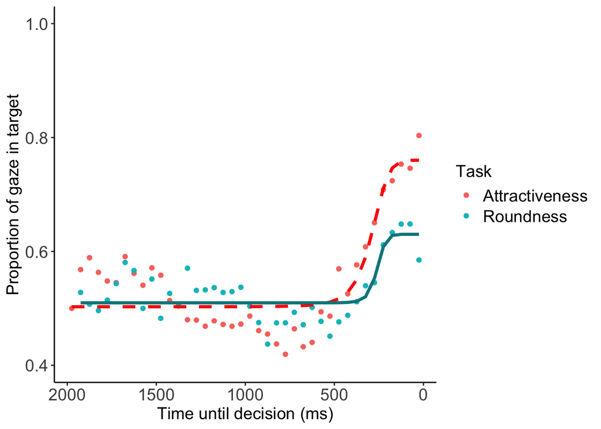